# Analysis of Superstore Furniture Sales Data

Yupawadee Galasong

2023-02-19

# Analyses to be performed

1. Summary statistics such as mean, median and standard deviation
2. Normality and Homogeneity of Variance check
3. One-Way ANOVA
4. Post-hoc test

# Introduction

The ‘Superstore’ dataset contains ~ 10,000 entries of sales data. The following information is recorded: order ID, order date, ship date, ship mode, customer information (name, address, segment), product information, sales, discount and profit. To begin the analysis, we import the dataset and reformat certain columns as needed.

```r
Superstore <- read_csv("../Data/Superstore.csv",
    col_types = cols(`Order Date` = col_date(format = "%m/%d/%Y"),
        `Ship Date` = col_date(format = "%m/%d/%Y")))
head(Superstore)
```

```
## # A tibble: 6 × 20
##   `Order ID`  `Order Date` `Ship Date` `Ship Mode` `Customer ID` `Customer Name`
##   <chr>       <date>       <date>      <chr>       <chr>         <chr>
## 1 CA-2016-15… 2016-11-08   2016-11-11  Second Cla… CG-12520      Claire Gute
## 2 CA-2016-15… 2016-11-08   2016-11-11  Second Cla… CG-12520      Claire Gute
## 3 CA-2016-13… 2016-06-12   2016-06-16  Second Cla… DV-13045      Darrin Van Huff
## 4 US-2015-10… 2015-10-11   2015-10-18  Standard C… SO-20335      Sean O'Donnell
## 5 US-2015-10… 2015-10-11   2015-10-18  Standard C… SO-20335      Sean O'Donnell
## 6 CA-2014-11… 2014-06-09   2014-06-14  Standard C… BH-11710      Brosina Hoffman
## # … with 14 more variables: Segment <chr>, Country <chr>, City <chr>,
## #   State <chr>, `Postal Code` <dbl>, Region <chr>, `Product ID` <chr>,
## #   Category <chr>, `Sub-Category` <chr>, `Product Name` <chr>, Sales <dbl>,
## #   Quantity <dbl>, Discount <dbl>, Profit <dbl>
```

# Calculating summary statistics

We might want to know the average sales and profits the store gained from different consumer segment. Using tidyverse (Wickham 2021) meta-package allows us to perform routine data science tasks such as computing summary statistics and grouping data frame.

```r
#Average sales and profit grouped by customer segment and region
Superstore %>%
  group_by(Segment) %>%
  summarise(
          count = n(),
          avg_sales = mean(Sales),
          avg_profit = mean(Profit)
            )
```

```
## # A tibble: 3 × 4
##   Segment     count avg_sales avg_profit
##   <chr>       <int>     <dbl>      <dbl>
## 1 Consumer     5191      224.       25.8
## 2 Corporate    3020      234.       30.5
## 3 Home Office  1783      241.       33.8
```

```r
#Maximum sales and profits grouped by region
Superstore %>%
  group_by(Region) %>%
  summarise(
          count = n(),
          max_sales = max(Sales),
          min_sales = min(Sales),
          max_profit = max(Profit),
          min_profit = min(Profit)
            )
```

```
## # A tibble: 4 × 6
##   Region  count max_sales min_sales max_profit min_profit
##   <chr>   <int>     <dbl>     <dbl>      <dbl>      <dbl>
## 1 Central  2323    17500.     0.444      8400.     -3702.
## 2 East     2848    11200.     0.852      5040.     -6600.
## 3 South    1620    22638.     1.17       3177.     -3840.
## 4 West     3203    14000.     0.99       6720.     -3400.
```

Alternatively, we can explore the median sales and profit generated from different product subcategory.

```r
#Median sales grouped by product sub-category
Superstore %>%
  group_by(`Sub-Category`) %>%
  summarise(
          count = n(),
          median_sales = median(Sales),
          median_profit = median(Profit)
            )
```

```
## # A tibble: 17 × 4
##    `Sub-Category` count median_sales median_profit
##    <chr>          <int>        <dbl>         <dbl>
##  1 Accessories      775        100           21
##  2 Appliances       466         82.7         17.4
##  3 Art              796         15.5          3.72
##  4 Binders         1523         18.6          3.98
##  5 Bookcases        228        307.           4.13
##  6 Chairs           617        362.          13.3
##  7 Copiers           68       1100.         333.
##  8 Envelopes        254         29.0         12.7
##  9 Fasteners        217         10.6          2.84
## 10 Furnishings      957         42.0          9.10
## 11 Labels           364         14.9          6.87
## 12 Machines         115        600.          39.0
## 13 Paper           1370         26.7         11.5
## 14 Phones           889        210.          23.5
## 15 Storage          846        114.           7.76
## 16 Supplies         190         27.9          3.96
## 17 Tables           319        448.         -31.4
```

# Visualizing sales data in the furniture category

We might want to know if sales and profit are normally distributed. We can visualize these data using histograms.

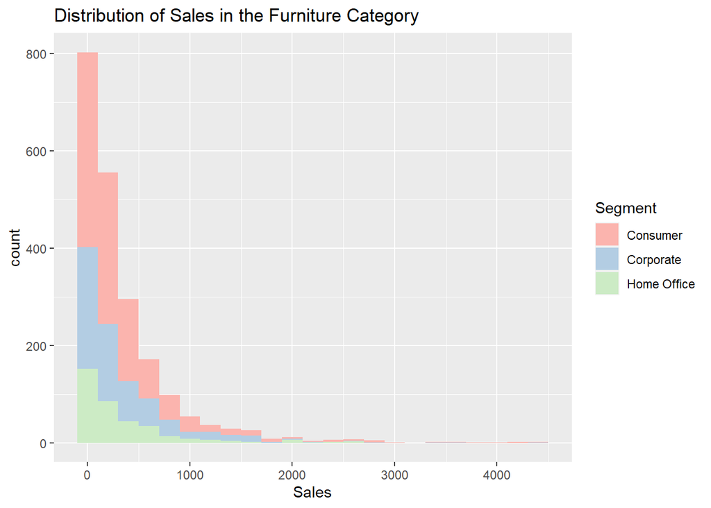

```r
ggplot(data = filter(Superstore, Category == "Furniture"), aes(x = Sales, fill = Segment)) + geom_histogram(binwidth = 200) + scale_fill_brewer(palette = "Pastel1") + labs(title = "Distribution of Sales in the Furniture Category")
```

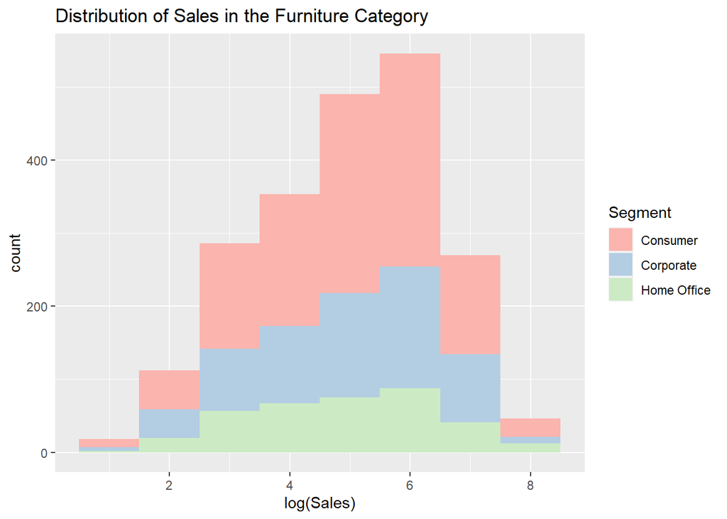

```r
ggplot(data = filter(Superstore, Category == "Furniture"), aes(x = log(Sales), fill = Segment)) + geom_histogram(binwidth = 1) + scale_fill_brewer(palette = "Pastel1") + labs(title = "Distribution of Sales in the Furniture Category")
```

```r
#Save the plot
ggsave("Histogram of Furniture Sales.png")
```

# Statistical comparison of sales data in the furniture category

Let’s create a new data frame by subsetting the initial Superstore dataset.

```r
Furniture = subset(Superstore, Category == "Furniture")
```

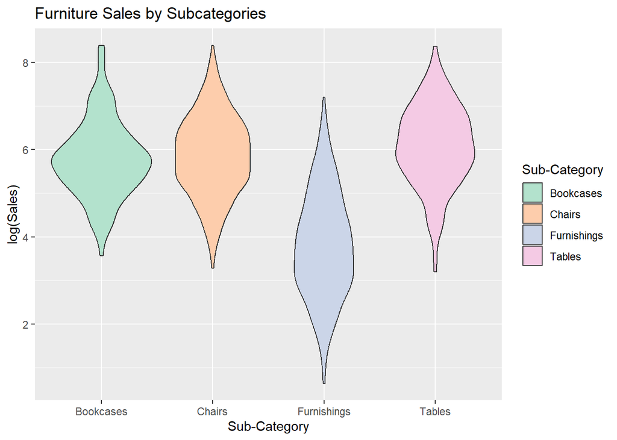

```r
ggplot(data = Furniture, aes(x = `Sub-Category`, y = log(Sales),fill = `Sub-Category`))+ geom_violin()+labs(title = "Furniture Sales by Subcategories ")+scale_fill_brewer(palette = "Pastel2")
```

## Checking normality assumption

Before performing Analysis of Variance (ANOVA), we should make sure that the data meets certain assumptions, one of which is the normality assumption. Normality is generally visualized using QQplot.

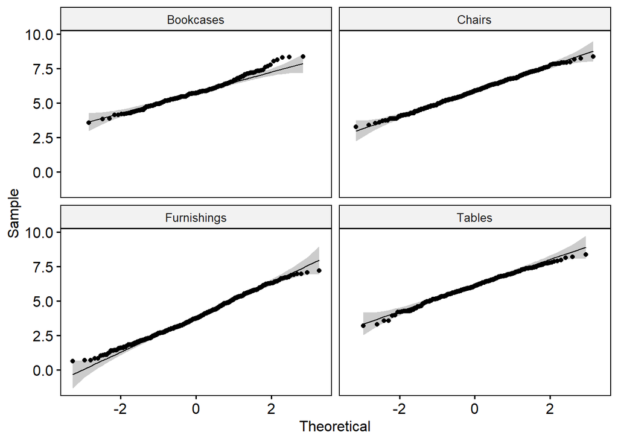

```r
#Add a new column of log-transformed sales to the Furniture dataframe because ggqqplot cannot accept log(Sales) as input.
Furniture$log_Sales = log(Furniture$Sales)

#QQ plot
ggqqplot(Furniture, "log_Sales", facet.by = "Sub-Category")
```

All the points fall approximately along the reference line, for each cell. So we can assume normality of the log-transformed sales data.

## Checking the assumption of homogeneity of variances

Levene’s test can be used to check the homogeneity of variances; i.e. if variances are equal.

```r
#Displaying results in a tibble
Furniture %>% levene_test(log_Sales ~ `Sub-Category`)
```

```
## # A tibble: 1 × 4
##     df1   df2 statistic        p
##   <int> <int>     <dbl>    <dbl>
## 1     3  2117      29.5 1.13e-18
```

## Welch One-Way ANOVA Test

```r
#Convert Sub-Category to a factor
Furniture$`Sub-Category` <- as.factor(Furniture$`Sub-Category`)

#Run the test
Furniture %>% welch_anova_test(log_Sales~`Sub-Category`)
```

```
## # A tibble: 1 × 7
##   .y.           n statistic   DFn   DFd        p method
## * <chr>     <int>     <dbl> <dbl> <dbl>    <dbl> <chr>
## 1 log_Sales  2121      649.     3  770. 2.7e-210 Welch ANOVA
```

One-way ANOVA with Welch test suggests that at least one of the subcategories has a significantly different sales compared to others. We will proceed with a post-hoc test to determine the significant sub-category. There are multiple post-hoc test available depending on the assumptions about the data. We know from the Levene’s test that our furniture sales data have unequal variances. Next, we need to find out if the sample sizes among the sub-categories are equal.

```r
#Another summary statistics of furniture sub-category
Furniture %>%
  group_by(`Sub-Category`) %>%
  summarise(
          count = n(),
          mean_sales = mean(Sales),
          SD_sales = sd(Sales))
```

```
## # A tibble: 4 × 4
##   `Sub-Category` count mean_sales SD_sales
##   <fct>          <int>      <dbl>    <dbl>
## 1 Bookcases        228      504.      639.
## 2 Chairs           617      532.      550.
## 3 Furnishings      957       95.8     148.
## 4 Tables           319      649.      616.
```

Since the sample size is also unequal, the following post-hoc tests are appropriate: Dunette’s test, Games-Howell test and Tamhane test. Let’s use Games-Howell test.

```r
Furniture %>% rename("SubCategory" = "Sub-Category") %>% games_howell_test(log_Sales~SubCategory)
```

```
## # A tibble: 6 × 8
##   .y.       group1      group2    estimate conf.low conf.high p.adj p.adj.signif
## * <chr>     <chr>       <chr>        <dbl>    <dbl>     <dbl> <dbl> <chr>
## 1 log_Sales Bookcases   Chairs      0.0775  -0.101      0.256 0.677 ns
## 2 log_Sales Bookcases   Furnishi…  -1.97    -2.15      -1.79  0     ****
## 3 log_Sales Bookcases   Tables      0.295    0.0937     0.496 0.001 ***
## 4 log_Sales Chairs      Furnishi…  -2.05    -2.19      -1.91  0     ****
## 5 log_Sales Chairs      Tables      0.218    0.0531     0.382 0.004 **
## 6 log_Sales Furnishings Tables      2.27     2.10       2.44  0     ****
```

Games-Howell test shows that all pairwise comparisons, except for Bookcases Vs Chairs, yield significant results. To visualize the statistical significance on a plot, we have to save the test results to a new data frame.

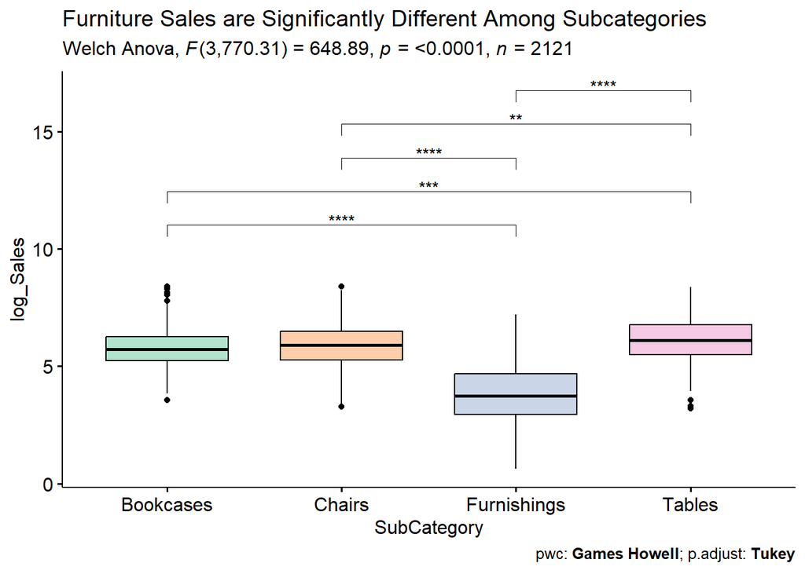

```r
# Welch One way ANOVA test

welch.aov <- Furniture %>% welch_anova_test(log_Sales~`Sub-Category`)

# Pairwise comparisons (Games-Howell)
pwc <- Furniture %>% rename("SubCategory" = "Sub-Category") %>% games_howell_test(log_Sales~SubCategory)

# Visualization: box plots with p-values
pwc <- pwc %>% add_y_position(step.increase = 1)
ggboxplot(Furniture %>% rename("SubCategory" = "Sub-Category") ,
          x = "SubCategory", y = "log_Sales", fill = "SubCategory")+
  scale_fill_brewer(palette = "Pastel2") +
  stat_pvalue_manual(pwc, hide.ns = TRUE, label = "p.adj.signif") +
  labs(
    title = "Furniture Sales are Significantly Different Among Subcategories",
    subtitle = get_test_label(welch.aov, detailed = TRUE),
    caption = get_pwc_label(pwc)) + theme(legend.position = "none")
```

Finally, let’s try fitting a linear model on the furniture data. We will use lm() function to fit a model. We can also include interaction terms, for example, Segment*Region to see if those predictors together can significantly affects the outcome.

```r
lm.fit <- lm(log_Sales~`Sub-Category`+Segment + Region+ Quantity+Discount+`Ship Mode`+Segment:Region, data = Furniture)
summary(lm.fit)
```

```
##
## Call:
## lm(formula = log_Sales ~ `Sub-Category` + Segment + Region +
##     Quantity + Discount + `Ship Mode` + Segment:Region, data = Furniture)
##
## Residuals:
##      Min       1Q   Median       3Q      Max
## -2.58328 -0.59958 -0.00341  0.57301  2.65268
##
## Coefficients:
##                                 Estimate Std. Error t value Pr(>|t|)
## (Intercept)                     5.215782   0.105883  49.260  < 2e-16 ***
## `Sub-Category`Chairs            0.027288   0.069632   0.392   0.6952
## `Sub-Category`Furnishings      -2.039503   0.066577 -30.634  < 2e-16 ***
## `Sub-Category`Tables            0.339876   0.077956   4.360 1.36e-05 ***
## SegmentCorporate               -0.177324   0.094917  -1.868   0.0619 .
## SegmentHome Office             -0.067323   0.109938  -0.612   0.5404
## RegionEast                      0.024313   0.078122   0.311   0.7557
## RegionSouth                     0.056613   0.090156   0.628   0.5301
## RegionWest                     -0.119054   0.075750  -1.572   0.1162
## Quantity                        0.234145   0.008623  27.153  < 2e-16 ***
## Discount                       -1.233362   0.119430 -10.327  < 2e-16 ***
## `Ship Mode`Same Day            -0.084383   0.096044  -0.879   0.3797
## `Ship Mode`Second Class        -0.085206   0.065775  -1.295   0.1953
## `Ship Mode`Standard Class       0.012014   0.055666   0.216   0.8291
## SegmentCorporate:RegionEast     0.175374   0.125279   1.400   0.1617
## SegmentHome Office:RegionEast  -0.012903   0.150668  -0.086   0.9318
## SegmentCorporate:RegionSouth   -0.136306   0.146289  -0.932   0.3516
## SegmentHome Office:RegionSouth -0.090656   0.179354  -0.505   0.6133
## SegmentCorporate:RegionWest     0.277683   0.122378   2.269   0.0234 *
## SegmentHome Office:RegionWest   0.136607   0.144139   0.948   0.3434
## ---
## Signif. codes:  0 '***' 0.001 '**' 0.01 '*' 0.05 '.' 0.1 ' ' 1
##
## Residual standard error: 0.8919 on 2101 degrees of freedom
## Multiple R-squared:  0.6449, Adjusted R-squared:  0.6416
## F-statistic: 200.8 on 19 and 2101 DF,  p-value: < 2.2e-16
```

The model summary also shows that the R-squared value is 0.64, meaning that only 64% of the variances in the sales data can be explained by the list of predictors we chose for this model.

# Conclusion

We explored the Superstore sales data with the emphasis on furniture sales data. One-way ANOVA test with Welch statistic shows that the furniture subcategories have significantly different sales. Finally, we fit a linear model with an interaction term and obtained a model with an R-squared value of 0.64.

# Bibliography

Kassambara, Alboukadel. 2023a. *Ggpubr: Ggplot2 Based Publication Ready Plots*. https://rpkgs.datanovia.com/ggpubr/.

———. 2023b. *Rstatix: Pipe-Friendly Framework for Basic Statistical Tests*. https://rpkgs.datanovia.com/rstatix/.

R Core Team. 2022. *R: A Language and Environment for Statistical Computing*. Vienna, Austria: R Foundation for Statistical Computing. https://www.R-project.org/.

Wickham, Hadley. 2021. *Tidyverse: Easily Install and Load the Tidyverse*. https://CRAN.R-project.org/package=tidyverse.

Wickham, Hadley, Mara Averick, Jennifer Bryan, Winston Chang, Lucy D’Agostino McGowan, Romain François, Garrett Grolemund, et al. 2019. “Welcome to the tidyverse.” *Journal of Open Source Software* 4 (43): 1686. https://doi.org/10.21105/joss.01686.